# tutoR, Day 2

David J. Harris

December 7, 2014

# (some more) general R resources

- [Hadley Wickham’s Advanced R book](http://adv-r.had.co.nz/)
- [Noam Ross’s blog](http://www.noamross.net/tags.html) (scroll down to the **R** tag)
  - [Collaborating with R](http://www.noamross.net/blog/2013/1/7/collaborating-with-r.html)
- Davis R Users Group: [main page with resources](http://www.noamross.net/davis-r-users-group.html) and [mailing list](https://groups.google.com/forum/#!forum/davis-rug)

# Reproducible research documents

- Keep everything in sync
  - Automatic updating of the document
  - Reduce ambiguity
- [R Markdown](http://rmarkdown.rstudio.com/)
- [Markdown basics](http://rmarkdown.rstudio.com/authoring_basics.html)
- [R code chunks](http://rmarkdown.rstudio.com/authoring_rcodechunks.html)
- [Shiny: Interactive web applications with R](http://shiny.rstudio.com/)
  - [Official tutorial](http://shiny.rstudio.com/tutorial/)
  - [Davis R Users Group tutorial](http://www.noamross.net/blog/2014/1/28/rpeekshiny.html)
- `spin` function in the `knitr` package allows you to turn regular R scripts into RMarkdown

# Data management

- The short version:
  - One “thing” per cell
  - One row per replicate
  - One column per variable
  - Long “better” than wide
    - reshape2 package lets you convert back and forth.
    - Maybe similar functionality in dplyr?
  - Don’t rely on anything that isn’t text
  - Make sure Excel doesn’t get too *creative*
- [1 Nine simple ways to make it easier to (re)use your data](https://peerj.com/preprints/7.pdf)
- [Christie Bahlai’s blog: Practical Data Management for Bug Counters](https://practicaldatamanagement.wordpress.com/) and her [#otherpeople’s data saga](https://storify.com/neoninc/otherpeoplesdata)
  - [Excel tips](https://practicaldatamanagement.wordpress.com/2013/12/16/excel-is-not-your-lab-notebook/)
  - [Excel dates](https://practicaldatamanagement.wordpress.com/2014/07/02/dealing-with-dates-as-data-in-excel/)
  - [In progress manuscript?](https://docs.google.com/document/d/12S34XlShpDvAargH76yhgzvWZm4EHGzDRX95tpK6To0/edit#heading=h.ve7byhxezdxv)
  - [Data Carpentry](https://practicaldatamanagement.wordpress.com/2014/09/04/teaching-students-how-to-data-some-reflections/)
- [OpenRefine](https://practicaldatamanagement.wordpress.com/2014/05/16/help-me-im-covered-in-bees-or-using-openrefine-to-clean-specimen-data/) for systematically cleaning up typos etc.

# Functions and environments

- Why functions?
  - Easy to re-use code
  - All your different `x` values can live safely in their own environments
- [Cosma Shalizi’s Statistical Computing slides](http://www.stat.cmu.edu/~cshalizi/statcomp/14/)
  - [Functions 1: slides](http://www.stat.cmu.edu/~cshalizi/statcomp/14/lectures/06/lecture-06.html#/)
  - [Functions 2: slides](http://www.stat.cmu.edu/~cshalizi/statcomp/14/lectures/07/lecture-07.html#1)
- Advanced R:
  - [Functions](http://adv-r.had.co.nz/Functions.html)
  - [Environments](http://adv-r.had.co.nz/Environments.html)
  - [Functional programming](http://adv-r.had.co.nz/Functional-programming.html)
  - [Functionals (functions of functions)](http://adv-r.had.co.nz/Functionals.html)
  - [Function operators](http://adv-r.had.co.nz/Function-operators.html)

# Text, regular expressions (advanced find-and-replace)

- [Cosma Shalizi’s statistical computing course](http://www.stat.cmu.edu/~cshalizi/statcomp/14/)
  - [introduction to strings](http://www.stat.cmu.edu/~cshalizi/statcomp/14/lectures/04/lecture-04.html#/)
  - [Regular expressions](http://www.stat.cmu.edu/~cshalizi/statcomp/14/lectures/05/lecture-05.html#/), [extra handout](http://www.stat.cmu.edu/~cshalizi/statcomp/14/lectures/05/regexp-handout.pdf)
- [Regular expression tutorial](http://regexone.com/)
- [Don’t parse HTML with regular expressions](https://stackoverflow.com/questions/1732348/regex-match-open-tags-except-xhtml-self-contained-tags/1732454#1732454)
- XKCD: [regex good](https://xkcd.com/208/), [regex bad](https://xkcd.com/1171/)

# Dates and times

- [Noam Ross’s blog post](http://www.noamross.net/blog/2014/2/10/using-times-and-dates-in-r---presentation-code.html)
- Hadley Wickham’s [lubridate package](http://cran.r-project.org/web/packages/lubridate/index.html)
- [ABANDON ALL HOPE, YE WHO ENTER DATES IN EXCEL](http://datapub.cdlib.org/2014/04/10/abandon-all-hope-ye-who-enter-dates-in-excel/)
- Christie Bahlai’s post on dates in Excel [?]
- Times are nearly as bad.

# Split-apply-combine

- The split-apply-combine
  - Divide your rows into related groups
  - Do something to each group
  - Put the results back together
- Automated with the plyr or dplyr packages
  - dplyr is amazing, but uses a different syntax from most of R. It’s also still very new
  - [lots more dplyr resources](http://www.dataschool.io/dplyr-tutorial-for-faster-data-manipulation-in-r/)
- Cosma Shalizi:
  - [Split-apply-combine in general](http://www.stat.cmu.edu/~cshalizi/statcomp/14/lectures/20/lecture-20.html#1)
  - [Split-apply-combine with plyr](http://www.stat.cmu.edu/~cshalizi/statcomp/14/lectures/21/lecture-21.html#1)
  - [More split-apply-combine](http://www.stat.cmu.edu/~cshalizi/statcomp/14/lectures/22/lecture-22.pdf)
- [dplyr vignette](http://cran.rstudio.com/web/packages/dplyr/vignettes/introduction.html)

# misc

- [ROpenSci packages](http://ropensci.org/packages/) for getting data
- The `manipulate` package (RStudio only) or [ggvis](http://ggvis.rstudio.com/) (any web browser) for interactive graphs without making a whole Shiny web app.

## Moving individual parts of a graph to left alignment

Problem: *all* words aligned left, not just the `main` “this is a graph” bit

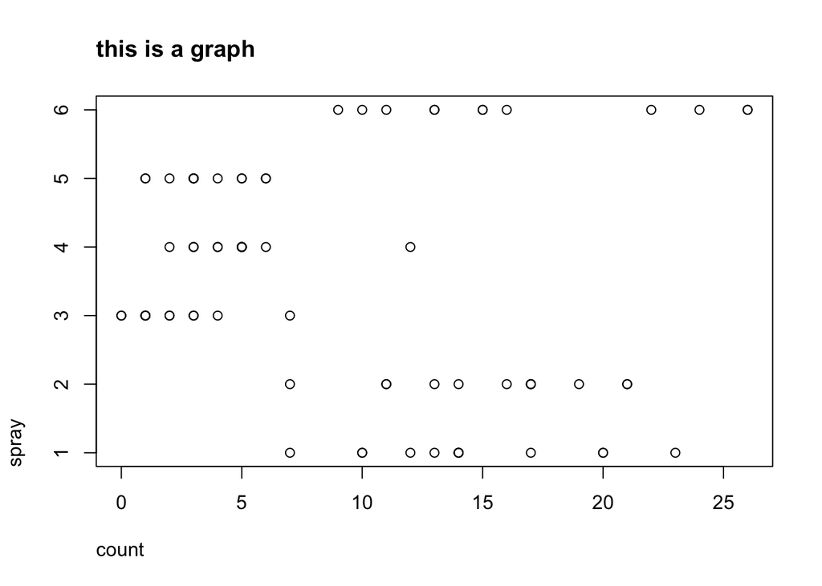

```r
par(adj = 0)
plot(InsectSprays, main = "this is a graph")
```

Possible solution: only use the `adj` parameter for the title, not for everything

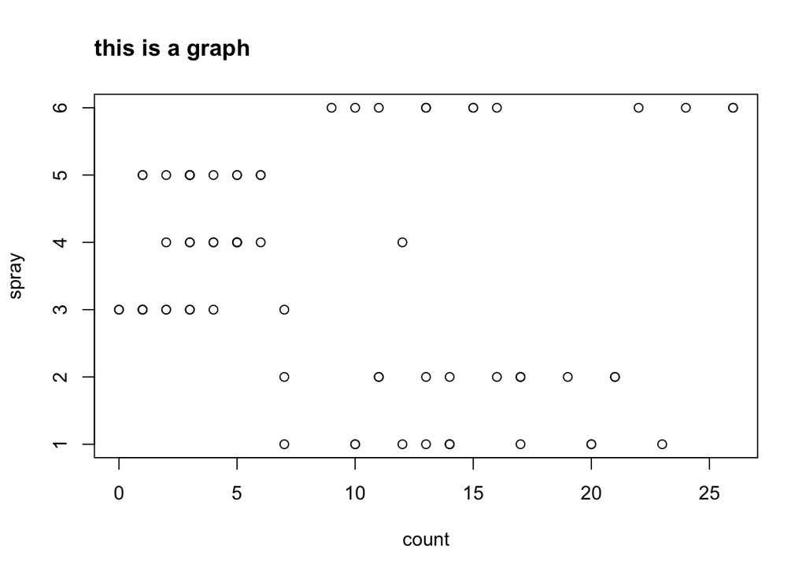

```r
plot(InsectSprays)
title("this is a graph", adj = 0)
```